# Bölmə 6: Tapşırıq Bankının Yaradılması

Kompüter Adaptiv Testləşmə (CAT) Tədrisi

CAT Tədrisi

2025-07-12

# 1 Giriş

Item Bank (Tapşırıq Bankı) CAT sisteminin ürəyidir. Keyfiyyətli və yaxşı strukturlaşdırılmış tapşırıq bankı CAT-ın effektivliyini, etibarlılığını və ədalətliliyini təmin edir. Bu bölmədə kompleks tapşırıq bankının necə yaradılacağını və idarə ediləcəyini öyrənəcəksiniz.

Tapşırıq bankı sadəcə tapşırıqların məcmusundan daha çox şeydir - bu, stratejik olaraq dizayn edilmiş, çoxölçülü məzmun strukturu və psixometrik xüsusiyyətlərə malik sistem komponentdir.

# 2 Tapşırıq Bankının Strukturu və Dizaynı

## 2.1 Bank Dizayn Prinsipləri

Keyfiyyətli tapşırıq bankı aşağıdakı prinsiplərə əsaslanır:

1. **Məzmun əhatəsi**: Bütün vacib mövzuları əhatə edir
2. **Çətinlik paylanması**: Geniş qabiliyyət aralığını əhatə edir
3. **Psixometrik keyfiyyət**: Yüksək ayrıd edicilik və uyğun parametrlər
4. **Təhlükəsizlik**: Tapşırıq məruz qalmasının minimizasiyası
5. **Operativ effektivlik**: İdarəetmə və yeniləmə rahatlığı

```r
# Bank dizayn prinsiplərini demonstrasiya edək
demonstrate_bank_principles <- function() {
    cat("=== TAPŞIRIQ BANKI DİZAYN PRİNSİPLƏRİ ===\n\n")

    # İdeal bank ölçüsü hesablaması
    max_test_length <- 30
    target_exposure_rate <- 0.20  # Hər tapşırığın istifadə tezliyi
    recommended_bank_size <- ceiling(max_test_length / target_exposure_rate)

    cat("1. BANK ÖLÇÜsÜ HESABLAMASi:\n")
    cat("   Maksimum test uzunluğu:", max_test_length, "tapşırıq\n")
    cat("   Hədəf exposure nisbəti:", target_exposure_rate, "\n")
    cat("   Tövsiyə edilən bank ölçüsü:", recommended_bank_size, "tapşırıq\n\n")

    # Çətinlik paylanması
    cat("2. ÇƏTİNLİK PAYLANMASI STRATEGİYASI:\n")
    difficulty_categories <- c("Çox asan", "Asan", "Orta-asan", "Orta",
                              "Orta-çətin", "Çətin", "Çox çətin")
    recommended_percentages <- c(10, 15, 20, 20, 20, 10, 5)

    for(i in 1:length(difficulty_categories)) {
        cat("   ", difficulty_categories[i], ":", recommended_percentages[i], "%\n")
    }

    cat("\n3. MƏZMUN BALANS STRATEGİYASI:\n")
    cat("   - Hər məzmun sahəsi üçün kifayət tapşırıq\n")
    cat("   - Bütün idrak səviyyələrinin təmsili\n")
    cat("   - Müxtəlif sual formatlarının daxil edilməsi\n")
}

demonstrate_bank_principles()
```

```
## === TAPŞIRIQ BANKI DİZAYN PRİNSİPLƏRİ ===
##
## 1. BANK ÖLÇÜsÜ HESABLAMASi:
##    Maksimum test uzunluğu: 30 tapşırıq
##    Hədəf exposure nisbəti: 0.2
##    Tövsiyə edilən bank ölçüsü: 150 tapşırıq
##
## 2. ÇƏTİNLİK PAYLANMASI STRATEGİYASI:
##     Çox asan : 10 %
##     Asan : 15 %
##     Orta-asan : 20 %
##     Orta : 20 %
##     Orta-çətin : 20 %
##     Çətin : 10 %
##     Çox çətin : 5 %
##
## 3. MƏZMUN BALANS STRATEGİYASI:
##    - Hər məzmun sahəsi üçün kifayət tapşırıq
##    - Bütün idrak səviyyələrinin təmsili
##    - Müxtəlif sual formatlarının daxil edilməsi
```

# 3 Tapşırıq Bankının Yaradılması

## 3.1 Əsas Bank Yaradma Funksiyası

```r
# 100 tapşırıqdan ibarət bank yaratmaq
create_item_bank <- function(n_items = 100, seed = 12345) {
    set.seed(seed)  # Təkrarlanabilir nəticələr üçün

    # Çətinlik səviyyələrinin stratifikasiyası
    difficulty_levels <- c(
        rep(-2.5, 10),  # Çox asan (10%)
        rep(-1.5, 15),  # Asan (15%)
        rep(-0.5, 20),  # Orta-asan (20%)
        rep(0.0, 20),   # Orta (20%)
        rep(0.5, 20),   # Orta-çətin (20%)
        rep(1.5, 10),   # Çətin (10%)
        rep(2.5, 5)     # Çox çətin (5%)
    )

    # Tapşırıq parametrlərinin yaradılması
    item_bank <- data.frame(
        item_id = 1:n_items,
        a = runif(n_items, 0.8, 2.5),    # Ayrıd edicilik
        b = difficulty_levels + rnorm(n_items, 0, 0.2),  # Çətinlik
        c = runif(n_items, 0.1, 0.25),   # Təsadüfi doğru cavab
        content_area = sample(c("Riyaziyyat", "Fizika", "Kimya",
                               "Biologiya", "Tarix"), n_items, replace = TRUE),
        cognitive_level = sample(c("Bilgi", "Anlayış", "Tətbiq",
                                  "Analiz", "Sintez"), n_items, replace = TRUE),
        time_limit = sample(60:180, n_items, replace = TRUE),  # saniyə
        difficulty_category = cut(difficulty_levels,
                                 breaks = c(-Inf, -2, -1, 0, 1, 2, Inf),
                                 labels = c("Çox asan", "Asan", "Orta-asan",
                                           "Orta-çətin", "Çətin", "Çox çətin")),
        created_date = Sys.Date(),
        last_used = as.Date(NA),
        usage_count = 0,
        exposure_rate = 0.0
    )

    # Parametr keyfiyyətini yoxlayın və düzəldin
    item_bank$a <- pmax(0.5, pmin(3.0, item_bank$a))  # a parametrini məhdudlaşdır
    item_bank$c <- pmax(0.05, pmin(0.4, item_bank$c)) # c parametrini məhdudlaşdır

    return(item_bank)
}

# Tapşırıq bankını yaradın
item_bank <- create_item_bank(100)

# İlk 5 tapşırığı göstər
cat("=== TAPŞIRIQ BANKI - İLK 5 TAPŞIRIQ ===\n")
```

```
## === TAPŞIRIQ BANKI - İLK 5 TAPŞIRIQ ===
```

```r
print(head(item_bank[, 1:8], 5))  # İlk 8 sütunu göstər
```

```
##   item_id        a         b         c content_area cognitive_level time_limit
## 1       1 2.025537 -2.608077 0.1079032        Kimya          Sintez        107
## 2       2 2.288814 -2.110461 0.1897986       Fizika           Bilgi        163
## 3       3 2.093670 -2.489282 0.2062436        Tarix          Sintez         99
## 4       4 2.306412 -2.429667 0.1980161        Kimya         Anlayış         99
## 5       5 1.576018 -2.634195 0.1866121   Riyaziyyat          Analiz         67
##   difficulty_category
## 1            Çox asan
## 2            Çox asan
## 3            Çox asan
## 4            Çox asan
## 5            Çox asan
```

## 3.2 Təkmilləşdirilmiş Bank Yaradma

```r
# Daha mürəkkəb tapşırıq bankı yaradma
create_advanced_item_bank <- function(n_items = 200,
                                     content_specifications = NULL,
                                     difficulty_distribution = "normal") {
    set.seed(12345)

    # Default məzmun spesifikasiyaları
    if (is.null(content_specifications)) {
        content_specifications <- list(
            "Riyaziyyat" = list(weight = 0.3, subcategories = c("Ədəd", "Cəbr", "Həndəsə")),
            "Elm" = list(weight = 0.4, subcategories = c("Fizika", "Kimya", "Biologiya")),
            "Dil" = list(weight = 0.2, subcategories = c("Qrammatika", "Oxu", "Yaz")),
            "Sosial" = list(weight = 0.1, subcategories = c("Tarix", "Coğrafiya"))
        )
    }

    # Çətinlik paylanması
    if (difficulty_distribution == "normal") {
        difficulties <- rnorm(n_items, 0, 1.2)
    } else if (difficulty_distribution == "uniform") {
        difficulties <- runif(n_items, -3, 3)
    } else {  # stratified
        difficulties <- create_stratified_difficulties(n_items)
    }

    # Məzmun sahələrini paylaşdır
    content_assignment <- assign_content_areas(n_items, content_specifications)

    # Bank yaradın
    advanced_bank <- data.frame(
        item_id = paste0("ITM", sprintf("%04d", 1:n_items)),
        a = generate_discrimination_params(n_items),
        b = difficulties,
        c = generate_guessing_params(n_items),
        content_area = content_assignment$main_area,
        subcategory = content_assignment$subcategory,
        cognitive_level = sample(c("Xatırla", "Anla", "Tətbiq et", "Təhlil et",
                                  "Qiymətləndir", "Yarat"), n_items, replace = TRUE,
                                prob = c(0.2, 0.25, 0.25, 0.15, 0.1, 0.05)),
        item_format = sample(c("MC4", "MC5", "TF", "SA"), n_items, replace = TRUE,
                            prob = c(0.6, 0.3, 0.05, 0.05)),
        time_limit = round(rnorm(n_items, 120, 30)),
        keywords = generate_keywords(n_items),
        author = sample(c("Tərtibçi_A", "Tərtibçi_B", "Tərtibçi_C"),
                       n_items, replace = TRUE),
        review_status = sample(c("Yeni", "Nəzərdən keçirilmiş", "Təsdiqlənmiş"),
                              n_items, replace = TRUE, prob = c(0.1, 0.3, 0.6)),
        created_date = sample(seq(as.Date('2023/01/01'), as.Date('2024/12/31'), by="day"),
                             n_items, replace = TRUE),
        stringsAsFactors = FALSE
    )

    return(advanced_bank)
}

# Köməkçi funksiyalar
create_stratified_difficulties <- function(n_items) {
    # Stratifikasiya edilmiş çətinlik paylanması
    strata <- c(-2.5, -1.5, -0.5, 0, 0.5, 1.5, 2.5)
    proportions <- c(0.05, 0.15, 0.25, 0.3, 0.15, 0.08, 0.02)

    difficulties <- c()
    for(i in 1:length(strata)) {
        n_in_stratum <- round(n_items * proportions[i])
        if(n_in_stratum > 0) {
            stratum_diffs <- rnorm(n_in_stratum, strata[i], 0.3)
            difficulties <- c(difficulties, stratum_diffs)
        }
    }

    # Lazım olarsa həcmi tam edin
    while(length(difficulties) < n_items) {
        difficulties <- c(difficulties, rnorm(1, 0, 1))
    }

    return(difficulties[1:n_items])
}

generate_discrimination_params <- function(n_items) {
    # Yüksək keyfiyyətli ayrıd edicilik parametrləri
    a_params <- rlnorm(n_items, meanlog = 0.2, sdlog = 0.3)
    a_params <- pmax(0.7, pmin(3.5, a_params))  # 0.7-3.5 aralığında məhdudlaşdır
    return(a_params)
}

generate_guessing_params <- function(n_items) {
    # Realistik təsadüfi cavab parametrləri
    c_params <- rbeta(n_items, 2, 10)  # Ortalama ~0.17
    c_params <- pmax(0.05, pmin(0.35, c_params))
    return(c_params)
}

assign_content_areas <- function(n_items, content_specs) {
    main_areas <- c()
    subcategories <- c()

    for(area in names(content_specs)) {
        n_for_area <- round(n_items * content_specs[[area]]$weight)
        if(n_for_area > 0) {
            main_areas <- c(main_areas, rep(area, n_for_area))
            subcats <- sample(content_specs[[area]]$subcategories, n_for_area, replace = TRUE)
            subcategories <- c(subcategories, subcats)
        }
    }

    # Lazım olarsa həcmi tam edin
    while(length(main_areas) < n_items) {
        area <- sample(names(content_specs), 1)
        main_areas <- c(main_areas, area)
        subcategories <- c(subcategories,
                          sample(content_specs[[area]]$subcategories, 1))
    }

    return(list(main_area = main_areas[1:n_items],
                subcategory = subcategories[1:n_items]))
}

generate_keywords <- function(n_items) {
    keyword_pool <- c("hesablama", "analiz", "sintez", "məntiq", "həll",
                     "tətbiq", "nəzəriyyə", "praktik", "müqayisə", "qiymətləndirmə")
    keywords <- sapply(1:n_items, function(x) {
        paste(sample(keyword_pool, sample(1:3, 1)), collapse = ", ")
    })
    return(keywords)
}

# Təkmilləşdirilmiş bank yaradın
advanced_bank <- create_advanced_item_bank(200)
cat("\n=== TƏKMİLLƏŞDİRİLMİŞ BANK - İLK 3 TAPŞIRIQ ===\n")
```

```
##
## === TƏKMİLLƏŞDİRİLMİŞ BANK - İLK 3 TAPŞIRIQ ===
```

```r
print(head(advanced_bank[, 1:10], 3))
```

```
##   item_id         a          b         c content_area subcategory
## 1 ITM0001 2.0391666  0.7026346 0.0500000   Riyaziyyat     Həndəsə
## 2 ITM0002 1.0701135  0.8513592 0.1682811   Riyaziyyat        Cəbr
## 3 ITM0003 0.8892331 -0.1311640 0.1531463   Riyaziyyat        Ədəd
##   cognitive_level item_format time_limit              keywords
## 1            Anla         MC5         91 analiz, praktik, həll
## 2       Təhlil et         MC4         72                  həll
## 3            Anla         MC4        123                sintez
```

# 4 Tapşırıq Bankının Təhlili və Vizuallaşdırılması

## 4.1 Bank Statistikalarının Təhlili

```r
# Tapşırıq bankının təhlili
analyze_item_bank <- function(bank) {
    cat("=== TAPŞIRIQ BANKI TƏHLİLİ ===\n\n")

    # Əsas statistikalar
    cat("1. ƏSAS STATİSTİKALAR:\n")
    cat("   Ümumi tapşırıq sayı:", nrow(bank), "\n")
    cat("   Orta çətinlik (b):", round(mean(bank$b), 3), "\n")
    cat("   Çətinlik standart sapması:", round(sd(bank$b), 3), "\n")
    cat("   Orta ayrıd edicilik (a):", round(mean(bank$a), 3), "\n")
    cat("   Orta təsadüfi cavab (c):", round(mean(bank$c), 3), "\n\n")

    # Çətinlik paylanması
    cat("2. ÇƏTİNLİK PAYLANMASI:\n")
    if("difficulty_category" %in% names(bank)) {
        diff_table <- table(bank$difficulty_category)
        for(i in 1:length(diff_table)) {
            cat("   ", names(diff_table)[i], ":", diff_table[i],
                "(", round(diff_table[i]/nrow(bank)*100, 1), "%)\n")
        }
    } else {
        # Çətinlik kateqoriyalarını yaradın
        diff_cats <- cut(bank$b, breaks = c(-Inf, -2, -1, 0, 1, 2, Inf),
                        labels = c("Çox asan", "Asan", "Orta-asan",
                                  "Orta-çətin", "Çətin", "Çox çətin"))
        diff_table <- table(diff_cats)
        for(i in 1:length(diff_table)) {
            cat("   ", names(diff_table)[i], ":", diff_table[i],
                "(", round(diff_table[i]/nrow(bank)*100, 1), "%)\n")
        }
    }

    cat("\n3. MƏZMUN SAHƏLƏRİ:\n")
    content_table <- table(bank$content_area)
    for(i in 1:length(content_table)) {
        cat("   ", names(content_table)[i], ":", content_table[i],
            "(", round(content_table[i]/nrow(bank)*100, 1), "%)\n")
    }

    cat("\n4. İDRAK SƏVİYYƏLƏRİ:\n")
    if("cognitive_level" %in% names(bank)) {
        cog_table <- table(bank$cognitive_level)
        for(i in 1:length(cog_table)) {
            cat("   ", names(cog_table)[i], ":", cog_table[i],
                "(", round(cog_table[i]/nrow(bank)*100, 1), "%)\n")
        }
    }

    # Keyfiyyət göstəriciləri
    cat("\n5. KEYFİYYƏT GÖSTƏRİCİLƏRİ:\n")
    low_discrimination <- sum(bank$a < 1.0)
    high_guessing <- sum(bank$c > 0.3)
    extreme_difficulty <- sum(abs(bank$b) > 3)

    cat("   Aşağı ayrıd edicilik (a < 1.0):", low_discrimination,
        "(", round(low_discrimination/nrow(bank)*100, 1), "%)\n")
    cat("   Yüksək təsadüfi cavab (c > 0.3):", high_guessing,
        "(", round(high_guessing/nrow(bank)*100, 1), "%)\n")
    cat("   Həddindən artıq çətinlik (|b| > 3):", extreme_difficulty,
        "(", round(extreme_difficulty/nrow(bank)*100, 1), "%)\n")
}

# Bank təhlili
analyze_item_bank(item_bank)
```

```
## === TAPŞIRIQ BANKI TƏHLİLİ ===
##
## 1. ƏSAS STATİSTİKALAR:
##    Ümumi tapşırıq sayı: 100
##    Orta çətinlik (b): -0.17
##    Çətinlik standart sapması: 1.25
##    Orta ayrıd edicilik (a): 1.666
##    Orta təsadüfi cavab (c): 0.181
##
## 2. ÇƏTİNLİK PAYLANMASI:
##     Çox asan : 10 ( 10 %)
##     Asan : 15 ( 15 %)
##     Orta-asan : 40 ( 40 %)
##     Orta-çətin : 20 ( 20 %)
##     Çətin : 10 ( 10 %)
##     Çox çətin : 5 ( 5 %)
##
## 3. MƏZMUN SAHƏLƏRİ:
##     Biologiya : 13 ( 13 %)
##     Fizika : 17 ( 17 %)
##     Kimya : 23 ( 23 %)
##     Riyaziyyat : 28 ( 28 %)
##     Tarix : 19 ( 19 %)
##
## 4. İDRAK SƏVİYYƏLƏRİ:
##     Analiz : 20 ( 20 %)
##     Anlayış : 23 ( 23 %)
##     Bilgi : 24 ( 24 %)
##     Sintez : 19 ( 19 %)
##     Tətbiq : 14 ( 14 %)
##
## 5. KEYFİYYƏT GÖSTƏRİCİLƏRİ:
##    Aşağı ayrıd edicilik (a < 1.0): 13 ( 13 %)
##    Yüksək təsadüfi cavab (c > 0.3): 0 ( 0 %)
##    Həddindən artıq çətinlik (|b| > 3): 0 ( 0 %)
```

## 4.2 Bank Vizuallaşdırılması

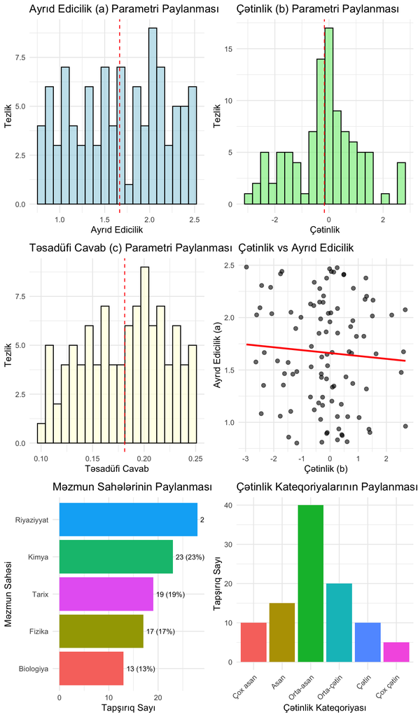

```r
# Tapşırıq bankının vizuallaşdırılması
visualize_item_bank <- function(bank) {

    # 1. Parametr paylanmaları
    p1 <- ggplot(bank, aes(x = a)) +
        geom_histogram(bins = 20, fill = "lightblue", color = "black", alpha = 0.7) +
        geom_vline(xintercept = mean(bank$a), color = "red", linetype = "dashed") +
        labs(title = "Ayrıd Edicilik (a) Parametri Paylanması",
             x = "Ayrıd Edicilik", y = "Tezlik") +
        theme_minimal()

    p2 <- ggplot(bank, aes(x = b)) +
        geom_histogram(bins = 20, fill = "lightgreen", color = "black", alpha = 0.7) +
        geom_vline(xintercept = mean(bank$b), color = "red", linetype = "dashed") +
        labs(title = "Çətinlik (b) Parametri Paylanması",
             x = "Çətinlik", y = "Tezlik") +
        theme_minimal()

    p3 <- ggplot(bank, aes(x = c)) +
        geom_histogram(bins = 20, fill = "lightyellow", color = "black", alpha = 0.7) +
        geom_vline(xintercept = mean(bank$c), color = "red", linetype = "dashed") +
        labs(title = "Təsadüfi Cavab (c) Parametri Paylanması",
             x = "Təsadüfi Cavab", y = "Tezlik") +
        theme_minimal()

    # 2. Parametr əlaqələri
    p4 <- ggplot(bank, aes(x = b, y = a)) +
        geom_point(alpha = 0.6, size = 2) +
        geom_smooth(method = "lm", se = FALSE, color = "red") +
        labs(title = "Çətinlik vs Ayrıd Edicilik",
             x = "Çətinlik (b)", y = "Ayrıd Edicilik (a)") +
        theme_minimal()

    # 3. Məzmun sahələrinin paylanması
    content_data <- bank %>%
        count(content_area) %>%
        mutate(percentage = round(n/sum(n)*100, 1))

    p5 <- ggplot(content_data, aes(x = reorder(content_area, n), y = n, fill = content_area)) +
        geom_col() +
        geom_text(aes(label = paste0(n, " (", percentage, "%)")),
                  hjust = -0.1, size = 3) +
        coord_flip() +
        labs(title = "Məzmun Sahələrinin Paylanması",
             x = "Məzmun Sahəsi", y = "Tapşırıq Sayı") +
        theme_minimal() +
        theme(legend.position = "none")

    # 4. Çətinlik kateqoriyaları
    if("difficulty_category" %in% names(bank)) {
        p6 <- ggplot(bank, aes(x = difficulty_category, fill = difficulty_category)) +
            geom_bar() +
            labs(title = "Çətinlik Kateqoriyalarının Paylanması",
                 x = "Çətinlik Kateqoriyası", y = "Tapşırıq Sayı") +
            theme_minimal() +
            theme(axis.text.x = element_text(angle = 45, hjust = 1),
                  legend.position = "none")
    } else {
        bank$diff_cat <- cut(bank$b, breaks = c(-Inf, -2, -1, 0, 1, 2, Inf),
                            labels = c("Çox asan", "Asan", "Orta-asan",
                                      "Orta-çətin", "Çətin", "Çox çətin"))
        p6 <- ggplot(bank, aes(x = diff_cat, fill = diff_cat)) +
            geom_bar() +
            labs(title = "Çətinlik Kateqoriyalarının Paylanması",
                 x = "Çətinlik Kateqoriyası", y = "Tapşırıq Sayı") +
            theme_minimal() +
            theme(axis.text.x = element_text(angle = 45, hjust = 1),
                  legend.position = "none")
    }

    # Bütün qrafikleri birləşdir
    grid.arrange(p1, p2, p3, p4, p5, p6, ncol = 2)
}

# Bank vizuallaşdırması
visualize_item_bank(item_bank)
```

# 5 Bank Keyfiyyətinin Qiymətləndirilməsi

## 5.1 Psixometrik Keyfiyyət Yoxlaması

```r
# Bank keyfiyyətinin qiymətləndirilməsi
assess_bank_quality <- function(bank) {
    cat("=== BANK KEYFİYYƏTİ QİYMƏTLƏNDİRMƏSİ ===\n\n")

    # Keyfiyyət kriteriləri
    quality_criteria <- list(
        discrimination_threshold = 1.0,  # a > 1.0
        guessing_threshold = 0.3,        # c < 0.3
        difficulty_range = c(-3, 3),     # -3 < b < 3
        min_content_representation = 10  # Hər məzmun sahəsi üçün minimum
    )

    # 1. Ayrıd edicilik keyfiyyəti
    high_discrimination <- sum(bank$a >= quality_criteria$discrimination_threshold)
    discrimination_score <- high_discrimination / nrow(bank) * 100

    cat("1. AYRID EDİCİLİK KEYFİYYƏTİ:\n")
    cat("   Yüksək ayrıd edicilik (a ≥ 1.0):", high_discrimination, "/", nrow(bank),
        "(", round(discrimination_score, 1), "%)\n")

    if(discrimination_score >= 80) {
        cat("   Qiymət: ✅ Əla\n")
    } else if(discrimination_score >= 60) {
        cat("   Qiymət: ⚡ Yaxşı\n")
    } else {
        cat("   Qiymət: ⚠️ Təkmilləşdirməyə ehtiyac\n")
    }

    # 2. Təsadüfi cavab keyfiyyəti
    low_guessing <- sum(bank$c < quality_criteria$guessing_threshold)
    guessing_score <- low_guessing / nrow(bank) * 100

    cat("\n2. TƏSADÜFI CAVAB KEYFİYYƏTİ:\n")
    cat("   Aşağı təsadüfi cavab (c < 0.3):", low_guessing, "/", nrow(bank),
        "(", round(guessing_score, 1), "%)\n")

    if(guessing_score >= 90) {
        cat("   Qiymət: ✅ Əla\n")
    } else if(guessing_score >= 75) {
        cat("   Qiymət: ⚡ Yaxşı\n")
    } else {
        cat("   Qiymət: ⚠️ Təkmilləşdirməyə ehtiyac\n")
    }

    # 3. Çətinlik aralığı
    appropriate_difficulty <- sum(bank$b >= quality_criteria$difficulty_range[1] &
                                 bank$b <= quality_criteria$difficulty_range[2])
    difficulty_score <- appropriate_difficulty / nrow(bank) * 100

    cat("\n3. ÇƏTİNLİK ARALIĞI KEYFİYYƏTİ:\n")
    cat("   Uyğun çətinlik (-3 ≤ b ≤ 3):", appropriate_difficulty, "/", nrow(bank),
        "(", round(difficulty_score, 1), "%)\n")

    if(difficulty_score >= 95) {
        cat("   Qiymət: ✅ Əla\n")
    } else if(difficulty_score >= 85) {
        cat("   Qiymət: ⚡ Yaxşı\n")
    } else {
        cat("   Qiymət: ⚠️ Təkmilləşdirməyə ehtiyac\n")
    }

    # 4. Məzmun əhatəsi
    content_counts <- table(bank$content_area)
    adequate_content <- sum(content_counts >= quality_criteria$min_content_representation)
    content_score <- adequate_content / length(content_counts) * 100

    cat("\n4. MƏZMUN ƏHATƏ KEYFİYYƏTİ:\n")
    cat("   Kifayət məzmun sahələri:", adequate_content, "/", length(content_counts),
        "(", round(content_score, 1), "%)\n")

    if(content_score >= 100) {
        cat("   Qiymət: ✅ Əla\n")
    } else if(content_score >= 80) {
        cat("   Qiymət: ⚡ Yaxşı\n")
    } else {
        cat("   Qiymət: ⚠️ Təkmilləşdirməyə ehtiyac\n")
    }

    # Ümumi qiymət
    overall_score <- mean(c(discrimination_score, guessing_score,
                           difficulty_score, content_score))

    cat("\n5. ÜMUMİ KEYFİYYƏT BALI:\n")
    cat("   Ümumi bal:", round(overall_score, 1), "/100\n")

    if(overall_score >= 85) {
        cat("   Qiymət: ✅ Əla keyfiyyət - Bank CAT üçün hazırdır\n")
        bank_grade <- "A"
    } else if(overall_score >= 75) {
        cat("   Qiymət: ⚡ Yaxşı keyfiyyət - Kiçik təkmilləşdirmələr məsləhət görülür\n")
        bank_grade <- "B"
    } else if(overall_score >= 65) {
        cat("   Qiymət: ⚠️ Orta keyfiyyət - Təkmilləşdirmə lazımdır\n")
        bank_grade <- "C"
    } else {
        cat("   Qiymət: ❌ Aşağı keyfiyyət - Əsaslı yenidən işlənmə lazımdır\n")
        bank_grade <- "D"
    }

    return(list(
        overall_score = overall_score,
        discrimination_score = discrimination_score,
        guessing_score = guessing_score,
        difficulty_score = difficulty_score,
        content_score = content_score,
        grade = bank_grade
    ))
}

# Bank keyfiyyət qiymətləndirilməsi
quality_assessment <- assess_bank_quality(item_bank)
```

```
## === BANK KEYFİYYƏTİ QİYMƏTLƏNDİRMƏSİ ===
##
## 1. AYRID EDİCİLİK KEYFİYYƏTİ:
##    Yüksək ayrıd edicilik (a ≥ 1.0): 87 / 100 ( 87 %)
##    Qiymət: ✅ Əla
##
## 2. TƏSADÜFI CAVAB KEYFİYYƏTİ:
##    Aşağı təsadüfi cavab (c < 0.3): 100 / 100 ( 100 %)
##    Qiymət: ✅ Əla
##
## 3. ÇƏTİNLİK ARALIĞI KEYFİYYƏTİ:
##    Uyğun çətinlik (-3 ≤ b ≤ 3): 100 / 100 ( 100 %)
##    Qiymət: ✅ Əla
##
## 4. MƏZMUN ƏHATƏ KEYFİYYƏTİ:
##    Kifayət məzmun sahələri: 5 / 5 ( 100 %)
##    Qiymət: ✅ Əla
##
## 5. ÜMUMİ KEYFİYYƏT BALI:
##    Ümumi bal: 96.8 /100
##    Qiymət: ✅ Əla keyfiyyət - Bank CAT üçün hazırdır
```

## 5.2 Test Məlumat Funksiyasının Hesablanması

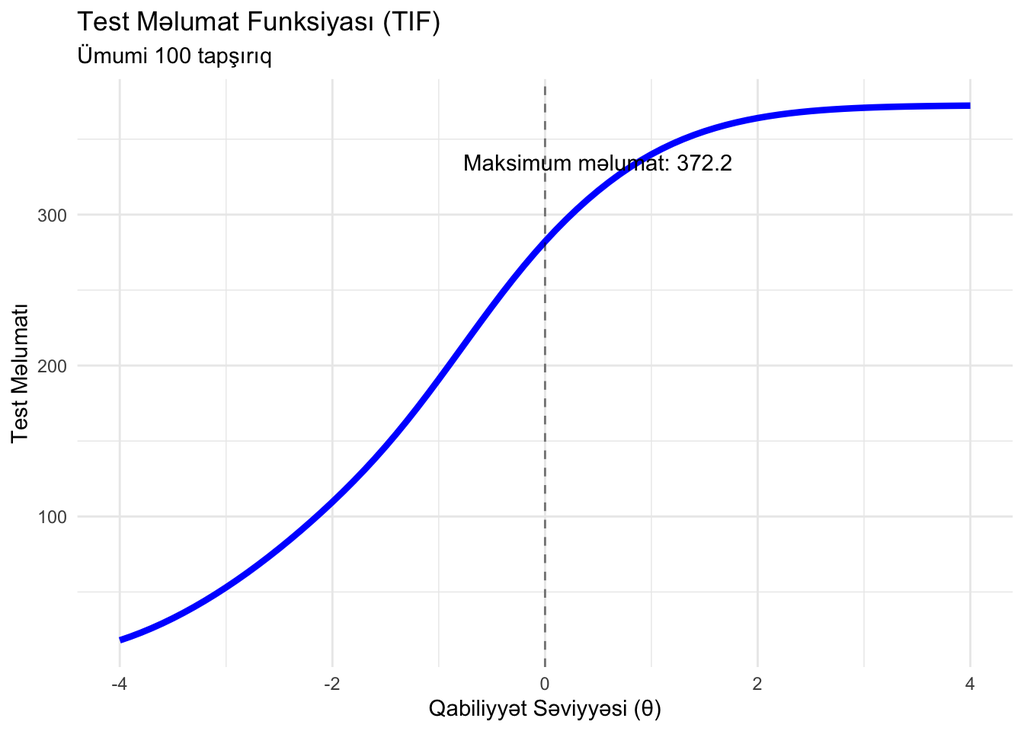

```r
# Test Məlumat Funksiyasının hesablanması
calculate_test_information <- function(bank, theta_range = c(-4, 4)) {

    theta <- seq(theta_range[1], theta_range[2], 0.1)
    total_information <- numeric(length(theta))

    # Hər tapşırıq üçün məlumat funksiyasını hesablayın
    for(i in 1:nrow(bank)) {
        a <- bank$a[i]
        b <- bank$b[i]
        c <- bank$c[i]

        # P(θ) hesablayın
        P <- c + (1 - c) * plogis(a * (theta - b))

        # İtem məlumat funksiyası: I(θ) = a² * P'(θ)² / [P(θ) * (1 - P(θ))]
        # P'(θ) = a * (1-c) * P(θ) * (1-P(θ)) / (1-c*Q(θ))
        Q <- 1 - P
        P_star <- (P - c) / (1 - c)
        Q_star <- 1 - P_star

        item_info <- (a^2 * P_star * Q_star) / (P * Q)

        # NaN dəyərləri 0 ilə əvəz edin
        item_info[is.nan(item_info) | is.infinite(item_info)] <- 0

        total_information <- total_information + item_info
    }

    return(data.frame(theta = theta, information = total_information))
}

# Test məlumat funksiyasını hesablayın və vizuallaşdırın
tif_data <- calculate_test_information(item_bank)

# TIF qrafiki
ggplot(tif_data, aes(x = theta, y = information)) +
    geom_line(size = 1.5, color = "blue") +
    labs(
        title = "Test Məlumat Funksiyası (TIF)",
        subtitle = paste("Ümumi", nrow(item_bank), "tapşırıq"),
        x = "Qabiliyyət Səviyyəsi (θ)",
        y = "Test Məlumatı"
    ) +
    theme_minimal() +
    geom_vline(xintercept = 0, linetype = "dashed", alpha = 0.5) +
    annotate("text", x = 0.5, y = max(tif_data$information) * 0.9,
             label = paste("Maksimum məlumat:", round(max(tif_data$information), 2)))
```

```r
# TIF statistikaları
cat("=== TEST MƏLUMAT FUNKSİYASI STATİSTİKALARI ===\n")
```

```
## === TEST MƏLUMAT FUNKSİYASI STATİSTİKALARI ===
```

```r
cat("Maksimum məlumat:", round(max(tif_data$information), 2), "\n")
```

```
## Maksimum məlumat: 372.2
```

```r
cat("Məlumat maksimumunun θ dəyəri:", tif_data$theta[which.max(tif_data$information)], "\n")
```

```
## Məlumat maksimumunun θ dəyəri: 4
```

```r
cat("θ = 0 nöqtəsində məlumat:", round(tif_data$information[tif_data$theta == 0], 2), "\n")
```

```
## θ = 0 nöqtəsində məlumat: 282.21
```

```r
cat("Orta məlumat (θ ∈ [-2, 2]):",
    round(mean(tif_data$information[tif_data$theta >= -2 & tif_data$theta <= 2]), 2), "\n")
```

```
## Orta məlumat (θ ∈ [-2, 2]): 262.9
```

# 6 Bank Optimallaşdırması və Təkmilləşdirmə

## 6.1 Bank Balansının Optimallaşdırılması

```r
# Bank balansını optimallaşdırma
optimize_bank_balance <- function(bank, target_difficulty_distribution = NULL) {

    if(is.null(target_difficulty_distribution)) {
        target_difficulty_distribution <- data.frame(
            category = c("Çox asan", "Asan", "Orta-asan", "Orta-çətin", "Çətin", "Çox çətin"),
            target_percent = c(10, 15, 25, 25, 15, 10),
            b_range_min = c(-Inf, -2, -1, 0, 1, 2),
            b_range_max = c(-2, -1, 0, 1, 2, Inf)
        )
    }

    cat("=== BANK BALANS OPTİMALLAŞDIRMASI ===\n\n")

    # Cari paylanma
    bank$difficulty_cat <- cut(bank$b,
                              breaks = c(-Inf, -2, -1, 0, 1, 2, Inf),
                              labels = target_difficulty_distribution$category)

    current_distribution <- bank %>%
        count(difficulty_cat) %>%
        mutate(current_percent = round(n / nrow(bank) * 100, 1))

    # Hədəf ilə müqayisə
    comparison <- merge(target_difficulty_distribution, current_distribution,
                       by.x = "category", by.y = "difficulty_cat", all = TRUE)
    comparison[is.na(comparison)] <- 0
    comparison$difference <- comparison$current_percent - comparison$target_percent

    cat("CARI vs HƏDƏF PAYLANMA:\n")
    print(comparison[, c("category", "target_percent", "current_percent", "difference")])

    # Optimallaşdırma tövsiyələri
    cat("\nOPTİMALLAŞDIRMA TOVSİYƏLƏRİ:\n")
    for(i in 1:nrow(comparison)) {
        if(abs(comparison$difference[i]) > 5) {
            if(comparison$difference[i] > 0) {
                cat("- ", comparison$category[i], "kateqoriyasında",
                    abs(round(comparison$difference[i])), "% artıq tapşırıq var\n")
            } else {
                cat("- ", comparison$category[i], "kateqoriyasında",
                    abs(round(comparison$difference[i])), "% az tapşırıq var\n")
            }
        }
    }

    return(comparison)
}

# Bank balansını optimallaşdır
balance_analysis <- optimize_bank_balance(item_bank)
```

```
## === BANK BALANS OPTİMALLAŞDIRMASI ===
##
## CARI vs HƏDƏF PAYLANMA:
##     category target_percent current_percent difference
## 1       Asan             15              15          0
## 2      Çətin             15              11         -4
## 3   Çox asan             10              10          0
## 4  Çox çətin             10               5         -5
## 5  Orta-asan             25              31          6
## 6 Orta-çətin             25              28          3
##
## OPTİMALLAŞDIRMA TOVSİYƏLƏRİ:
## -  Orta-asan kateqoriyasında 6 % artıq tapşırıq var
```

## 6.2 Problemli Tapşırıqların Aşkarlanması

```r
# Problemli tapşırıqları aşkarlayan funksiya
identify_problematic_items <- function(bank) {

    cat("=== PROBLEMLİ TAPŞIRIQLAR ANALİZİ ===\n\n")

    # Problem kriteriləri
    problems <- data.frame(
        item_id = bank$item_id,
        low_discrimination = bank$a < 0.8,
        high_guessing = bank$c > 0.35,
        extreme_difficulty = abs(bank$b) > 3,
        very_low_discrimination = bank$a < 0.5,
        negative_discrimination = bank$a < 0
    )

    # Hər tapşırıq üçün problem sayını hesablayın
    problems$total_problems <- rowSums(problems[, 2:6])

    # Problem kateqoriyaları
    severe_problems <- problems[problems$total_problems >= 3, ]
    moderate_problems <- problems[problems$total_problems == 2, ]
    minor_problems <- problems[problems$total_problems == 1, ]

    cat("PROBLEM KATEQORİYALARI:\n")
    cat("Ağır problemli tapşırıqlar (3+ problem):", nrow(severe_problems), "\n")
    cat("Orta problemli tapşırıqlar (2 problem):", nrow(moderate_problems), "\n")
    cat("Kiçik problemli tapşırıqlar (1 problem):", nrow(minor_problems), "\n")
    cat("Problemsiz tapşırıqlar:", nrow(bank) - nrow(severe_problems) -
        nrow(moderate_problems) - nrow(minor_problems), "\n\n")

    # Ağır problemli tapşırıqların detalları
    if(nrow(severe_problems) > 0) {
        cat("AĞIR PROBLEMLİ TAPŞIRIQLAR:\n")
        for(i in 1:min(10, nrow(severe_problems))) {  # İlk 10-u göstər
            item_id <- severe_problems$item_id[i]
            item_data <- bank[bank$item_id == item_id, ]
            cat("Tapşırıq", item_id, ": a =", round(item_data$a, 3),
                ", b =", round(item_data$b, 3), ", c =", round(item_data$c, 3), "\n")
        }
    }

    # Tövsiyələr
    cat("\nTƏKMİLLƏŞDİRMƏ TOVSİYƏLƏRİ:\n")
    if(nrow(severe_problems) > 0) {
        cat("1. Ağır problemli", nrow(severe_problems), "tapşırığı bankdan çıxarın\n")
    }
    if(nrow(moderate_problems) > 0) {
        cat("2. Orta problemli", nrow(moderate_problems), "tapşırığı yenidən nəzərdən keçirin\n")
    }
    if(nrow(minor_problems) > 0) {
        cat("3. Kiçik problemli", nrow(minor_problems), "tapşırığı izləyin\n")
    }

    return(list(
        severe = severe_problems,
        moderate = moderate_problems,
        minor = minor_problems,
        summary = problems
    ))
}

# Problemli tapşırıqları aşkar edin
problematic_items <- identify_problematic_items(item_bank)
```

```
## === PROBLEMLİ TAPŞIRIQLAR ANALİZİ ===
##
## PROBLEM KATEQORİYALARI:
## Ağır problemli tapşırıqlar (3+ problem): 0
## Orta problemli tapşırıqlar (2 problem): 0
## Kiçik problemli tapşırıqlar (1 problem): 0
## Problemsiz tapşırıqlar: 100
##
##
## TƏKMİLLƏŞDİRMƏ TOVSİYƏLƏRİ:
```

# 7 Bank İdarəetməsi və Təhlükəsizlik

## 7.1 Exposure Control Sistemləri

```
## === EXPOSURE CONTROL SİMULYASİYASI ===
##
## EXPOSURE STATİSTİKALARI:
## Orta exposure nisbəti: 0.201
## Maksimum exposure nisbəti: 0.343
## Minimum exposure nisbəti: 0.054
## Exposure standart sapması: 0.083
##
## YÜKSƏK EXPOSURE TAPŞIRIQLAR (> 0.4 ):
## Sayı: 0
##
## AŞAĞI EXPOSURE TAPŞIRIQLAR (< 0.05 ):
## Sayı: 0
```

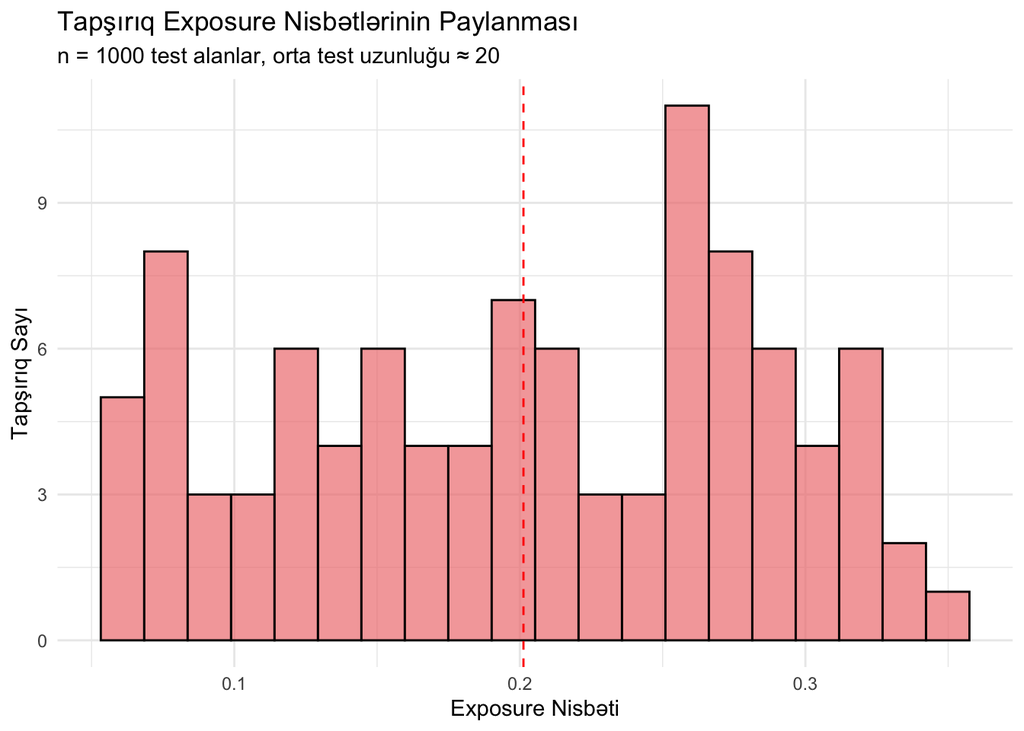

```r
# Exposure control sistemlərinin simulyasiyası
simulate_exposure_control <- function(bank, n_examinees = 1000, max_test_length = 25) {

    cat("=== EXPOSURE CONTROL SİMULYASİYASI ===\n\n")

    # Hər tapşırığın istifadə sayını simulyasiya edin
    set.seed(12345)

    # Sadə exposure simulyasiyası
    # Yüksək keyfiyyətli tapşırıqlar daha çox istifadə olunur
    quality_weights <- pmax(0.1, bank$a - 0.5)  # Ayrıd ediciliyə əsaslı çəki

    exposure_counts <- numeric(nrow(bank))

    for(examinee in 1:n_examinees) {
        # Hər test alan üçün təsadüfi test uzunluğu
        test_length <- sample(15:max_test_length, 1)

        # Çəkili təsadüfi seçim
        selected_items <- sample(1:nrow(bank), test_length,
                                prob = quality_weights, replace = FALSE)

        exposure_counts[selected_items] <- exposure_counts[selected_items] + 1
    }

    # Exposure nisbətlərini hesablayın
    bank$exposure_count <- exposure_counts
    bank$exposure_rate <- exposure_counts / n_examinees

    # Exposure statistikaları
    cat("EXPOSURE STATİSTİKALARI:\n")
    cat("Orta exposure nisbəti:", round(mean(bank$exposure_rate), 3), "\n")
    cat("Maksimum exposure nisbəti:", round(max(bank$exposure_rate), 3), "\n")
    cat("Minimum exposure nisbəti:", round(min(bank$exposure_rate), 3), "\n")
    cat("Exposure standart sapması:", round(sd(bank$exposure_rate), 3), "\n\n")

    # Yüksək exposure tapşırıqları
    high_exposure_threshold <- 0.4
    high_exposure_items <- bank[bank$exposure_rate > high_exposure_threshold, ]

    cat("YÜKSƏK EXPOSURE TAPŞIRIQLAR (>", high_exposure_threshold, "):\n")
    cat("Sayı:", nrow(high_exposure_items), "\n")
    if(nrow(high_exposure_items) > 0) {
        cat("Tapşırıq ID-ləri:", paste(head(high_exposure_items$item_id, 10), collapse = ", "), "\n")
    }

    # Aşağı exposure tapşırıqları
    low_exposure_threshold <- 0.05
    low_exposure_items <- bank[bank$exposure_rate < low_exposure_threshold, ]

    cat("\nAŞAĞI EXPOSURE TAPŞIRIQLAR (<", low_exposure_threshold, "):\n")
    cat("Sayı:", nrow(low_exposure_items), "\n")
    if(nrow(low_exposure_items) > 0) {
        cat("Tapşırıq ID-ləri:", paste(head(low_exposure_items$item_id, 10), collapse = ", "), "\n")
    }

    # Exposure paylanması vizuallaşdırması
    exposure_plot <- ggplot(bank, aes(x = exposure_rate)) +
        geom_histogram(bins = 20, fill = "lightcoral", color = "black", alpha = 0.7) +
        geom_vline(xintercept = mean(bank$exposure_rate), color = "red", linetype = "dashed") +
        labs(
            title = "Tapşırıq Exposure Nisbətlərinin Paylanması",
            subtitle = paste("n =", n_examinees, "test alanlar,", "orta test uzunluğu ≈",
                            round(mean(15:max_test_length))),
            x = "Exposure Nisbəti",
            y = "Tapşırıq Sayı"
        ) +
        theme_minimal()

    print(exposure_plot)

    return(bank)
}

# Exposure control simulyasiyası
bank_with_exposure <- simulate_exposure_control(item_bank, n_examinees = 1000)
```

## 7.2 Bank Təhlükəsizlik Qiymətləndirilməsi

```r
# Bank təhlükəsizliyinin qiymətləndirilməsi
assess_bank_security <- function(bank_with_exposure) {

    cat("=== BANK TƏHLÜKƏSİZLİK QİYMƏTLƏNDİRMƏSİ ===\n\n")

    # Təhlükəsizlik metriklər
    # 1. Exposure variasiyası
    exposure_cv <- sd(bank_with_exposure$exposure_rate) / mean(bank_with_exposure$exposure_rate)
    cat("1. EXPOSURE VARİASİYASI:\n")
    cat("   Coefficient of Variation:", round(exposure_cv, 3), "\n")

    if(exposure_cv < 0.3) {
        cat("   Qiymət: ✅ Yaxşı exposure balansı\n")
    } else if(exposure_cv < 0.5) {
        cat("   Qiymət: ⚡ Orta exposure balansı\n")
    } else {
        cat("   Qiymət: ⚠️ Zəif exposure balansı\n")
    }

    # 2. Tapşırıq pool ölçüsü
    max_test_length <- 25
    pool_ratio <- nrow(bank_with_exposure) / max_test_length
    cat("\n2. TAPŞIRIQ POOL ÖLÇÜsÜ:\n")
    cat("   Pool/Test nisbəti:", round(pool_ratio, 1), "\n")

    if(pool_ratio >= 5) {
        cat("   Qiymət: ✅ Kifayət bank ölçüsü\n")
    } else if(pool_ratio >= 3) {
        cat("   Qiymət: ⚡ Orta bank ölçüsü\n")
    } else {
        cat("   Qiymət: ⚠️ Kiçik bank ölçüsü\n")
    }

    # 3. Məzmun sahələrinin paylanması
    content_balance <- table(bank_with_exposure$content_area)
    content_cv <- sd(content_balance) / mean(content_balance)
    cat("\n3. MƏZMUN BALANSLAŞDIRMASI:\n")
    cat("   Məzmun CV:", round(content_cv, 3), "\n")

    if(content_cv < 0.3) {
        cat("   Qiymət: ✅ Yaxşı məzmun balansı\n")
    } else if(content_cv < 0.5) {
        cat("   Qiymət: ⚡ Orta məzmun balansı\n")
    } else {
        cat("   Qiymət: ⚠️ Zəif məzmun balansı\n")
    }

    # 4. Yüksək exposure risk
    high_risk_items <- sum(bank_with_exposure$exposure_rate > 0.5)
    risk_percentage <- high_risk_items / nrow(bank_with_exposure) * 100
    cat("\n4. YÜKSƏK EXPOSURE RİSKİ:\n")
    cat("   Yüksək risk tapşırıqları:", high_risk_items, "(", round(risk_percentage, 1), "%)\n")

    if(risk_percentage < 5) {
        cat("   Qiymət: ✅ Aşağı təhlükəsizlik riski\n")
    } else if(risk_percentage < 10) {
        cat("   Qiymət: ⚡ Orta təhlükəsizlik riski\n")
    } else {
        cat("   Qiymət: ⚠️ Yüksək təhlükəsizlik riski\n")
    }

    # Ümumi təhlükəsizlik bali
    security_score <- mean(c(
        ifelse(exposure_cv < 0.3, 100, ifelse(exposure_cv < 0.5, 75, 50)),
        ifelse(pool_ratio >= 5, 100, ifelse(pool_ratio >= 3, 75, 50)),
        ifelse(content_cv < 0.3, 100, ifelse(content_cv < 0.5, 75, 50)),
        ifelse(risk_percentage < 5, 100, ifelse(risk_percentage < 10, 75, 50))
    ))

    cat("\n5. ÜMUMİ TƏHLÜKƏSİZLİK BALI:", round(security_score, 1), "/100\n")

    if(security_score >= 85) {
        cat("   Qiymət: ✅ Yüksək təhlükəsizlik\n")
    } else if(security_score >= 70) {
        cat("   Qiymət: ⚡ Orta təhlükəsizlik\n")
    } else {
        cat("   Qiymət: ⚠️ Aşağı təhlükəsizlik - İyileşdirmə lazımdır\n")
    }

    return(security_score)
}

# Bank təhlükəsizlik qiymətləndirilməsi
security_score <- assess_bank_security(bank_with_exposure)
```

```
## === BANK TƏHLÜKƏSİZLİK QİYMƏTLƏNDİRMƏSİ ===
##
## 1. EXPOSURE VARİASİYASI:
##    Coefficient of Variation: 0.411
##    Qiymət: ⚡ Orta exposure balansı
##
## 2. TAPŞIRIQ POOL ÖLÇÜsÜ:
##    Pool/Test nisbəti: 4
##    Qiymət: ⚡ Orta bank ölçüsü
##
## 3. MƏZMUN BALANSLAŞDIRMASI:
##    Məzmun CV: 0.287
##    Qiymət: ✅ Yaxşı məzmun balansı
##
## 4. YÜKSƏK EXPOSURE RİSKİ:
##    Yüksək risk tapşırıqları: 0 ( 0 %)
##    Qiymət: ✅ Aşağı təhlükəsizlik riski
##
## 5. ÜMUMİ TƏHLÜKƏSİZLİK BALI: 87.5 /100
##    Qiymət: ✅ Yüksək təhlükəsizlik
```

# 8 Nəticə

Bu bölmədə CAT sistemləri üçün keyfiyyətli tapşırıq bankının necə yaradılacağını və idarə ediləcəyini öyrəndik. Tapşırıq bankı CAT-ın ürəyidir və onun keyfiyyəti sistemin ümumi performansını müəyyən edir.

## 8.1 Əsas Nəticələr

1. **Bank strukturu** məzmun, çətinlik və psixometrik xüsusiyyətləri balanslaşdırmalıdır
2. **Keyfiyyət nəzarəti** sistemli olaraq aparılmalı və problemli tapşırıqlar aşkarlanmalıdır
3. **Exposure control** tapşırıq təhlükəsizliyini təmin etmək üçün vacibdir
4. **Bank optimallaşdırması** davamlı proses olaraq aparılmalıdır
5. **Təhlükəsizlik qiymətləndirilməsi** bank etibarlılığını təmin edir

## 8.2 Tövsiyələr

- Bank ölçüsü maksimum test uzunluğunun ən azı 5 misli olmalıdır
- Hər məzmun sahəsində kifayət sayda tapşırıq olmalıdır
- Exposure nisbətləri mütəmadi izlənməli və optimallaşdırılmalıdır
- Problemli tapşırıqlar vaxtında aşkarlanmalı və əvəz edilməlidir

## 8.3 Növbəti Addımlar

- Bölmə 7: CAT Adaptiv Alqoritmlərinin Tənzimlənməsi
- Bölmə 8: CAT Simulyasiyalarının Aparılması
- Bölmə 9: CAT Performansının Qiymətləndirilməsi

**Qeyd**: Bu bölmədə yaradılan tapşırıq bankı simulyasiya məqsədli nümunədir. Real CAT sistemləri üçün empirik verilənlərdən əldə edilmiş və ekspert qiymətləndirilməsindən keçmiş tapşırıq parametrləri istifadə edilməlidir.